# Lab Assignment Five: Wide and Deep Networks

## Course: Machine Learning in Python

## Semester: Fall 2023

### Authors:

**Ritik Khandelwal (49347408)**

**Prashant Iyer (49352530)**

**Brian Ronald Mendes (49243148)**

### Team: Perceptron

### Business Understanding

**"Deposits"** - The term that helps the bank function smoothly. Every bank tries to get their customer to invest in different deposit schemes in their bank. They give good competetive interest rates and offers to keep the customer tied to the schemes. They promote such schemes through various mediums like cellular, telephonic, in-person, emails etc. Every bank tries to analyse various customer factors like their credit history, balances, salary, education etc. when defining the best rates that can be offered.

There is a marketing team that looks after this part of business. They find various ways to communicate the benefits of the deposit scheme to the customers. Some invest and some don't. This Bank Marketing dataset tries to look at all these factors as a whole to predict if a customer would invest or not. Thus, pro-active measures can be taken in the future to on board the right set of customers.

The Bank Marketing Dataset has 11162 rows and 17 attributes that includes both numerical and categorical variables. It originally belongs to the UCI Machine Learning Repository, but can be found on Kaggle as well. We can download this dataset for free from either of the websites.

Analyzing and Visualizing this information can help strategize the right set of customers and their deposit deals and terms. It should definitely give a better result than when chossing any random customers. This is a great step ahead in order to save time and resources of a bank. It gives them the right direction to proceed with in the next deposit campaign cycle.

Problem Addressed:

Which next customer would deposit (do investment) in the bank? Which customers should be included in the bank deposit strategy?

### Data Sources

#### Bank Marketing Dataset:

UCI: (https://archive.ics.uci.edu/dataset/222/bank+marketing)

Kaggle: (https://www.kaggle.com/datasets/janiobachmann/bank-marketing-dataset).

The research paper associated with this data can be found in the following journal:

**Paper Citation:** Moro, S., Cortez, P. & Rita, P. (2014). A data-driven approach to predict the success of bank telemarketing. Decision Support Systems. 62, 22-31 https://dx.doi.org/10.1016/j.dss.2014.03.001

```python
#Libraries used
import pandas as pd
import matplotlib.pyplot as plt
%matplotlib inline
import warnings
warnings.filterwarnings("ignore")
import seaborn as sns
import numpy as np
```

```python
df = pd.read_csv("bank.csv")
```

```python
df
```

|  | age | job | marital | education | default | balance | housing | loan | contact | day | month | duration | campaign | pdays | previous | poutcome | deposit |
| --- | --- | --- | --- | --- | --- | --- | --- | --- | --- | --- | --- | --- | --- | --- | --- | --- | --- |
| 0 | 59 | admin. | married | secondary | no | 2343 | yes | no | unknown | 5 | may | 1042 | 1 | -1 | 0 | unknown | yes |
| 1 | 56 | admin. | married | secondary | no | 45 | no | no | unknown | 5 | may | 1467 | 1 | -1 | 0 | unknown | yes |
| 2 | 41 | technician | married | secondary | no | 1270 | yes | no | unknown | 5 | may | 1389 | 1 | -1 | 0 | unknown | yes |
| 3 | 55 | services | married | secondary | no | 2476 | yes | no | unknown | 5 | may | 579 | 1 | -1 | 0 | unknown | yes |
| 4 | 54 | admin. | married | tertiary | no | 184 | no | no | unknown | 5 | may | 673 | 2 | -1 | 0 | unknown | yes |
| ... | ... | ... | ... | ... | ... | ... | ... | ... | ... | ... | ... | ... | ... | ... | ... | ... | ... |
| 11157 | 33 | blue-collar | single | primary | no | 1 | yes | no | cellular | 20 | apr | 257 | 1 | -1 | 0 | unknown | no |
| 11158 | 39 | services | married | secondary | no | 733 | no | no | unknown | 16 | jun | 83 | 4 | -1 | 0 | unknown | no |
| 11159 | 32 | technician | single | secondary | no | 29 | no | no | cellular | 19 | aug | 156 | 2 | -1 | 0 | unknown | no |
| 11160 | 43 | technician | married | secondary | no | 0 | no | yes | cellular | 8 | may | 9 | 2 | 172 | 5 | failure | no |
| 11161 | 34 | technician | married | secondary | no | 0 | no | no | cellular | 9 | jul | 628 | 1 | -1 | 0 | unknown | no |

11162 rows × 17 columns

### Data Description

[output not shown]

### Preprocessing

```python
df.rename(columns =  {'housing':'housing_loan','loan':'personal_loan','default':'credit_default','contact':'contact_mode','pdays':'days_since_last_contact'},inplace=True)
```

```python
df.describe()
```

|  | age | balance | day | duration | campaign | days_since_last_contact | previous |
| --- | --- | --- | --- | --- | --- | --- | --- |
| count | 11162.000000 | 11162.000000 | 11162.000000 | 11162.000000 | 11162.000000 | 11162.000000 | 11162.000000 |
| mean | 41.231948 | 1528.538524 | 15.658036 | 371.993818 | 2.508421 | 51.330407 | 0.832557 |
| std | 11.913369 | 3225.413326 | 8.420740 | 347.128386 | 2.722077 | 108.758282 | 2.292007 |
| min | 18.000000 | -6847.000000 | 1.000000 | 2.000000 | 1.000000 | -1.000000 | 0.000000 |
| 25% | 32.000000 | 122.000000 | 8.000000 | 138.000000 | 1.000000 | -1.000000 | 0.000000 |
| 50% | 39.000000 | 550.000000 | 15.000000 | 255.000000 | 2.000000 | -1.000000 | 0.000000 |
| 75% | 49.000000 | 1708.000000 | 22.000000 | 496.000000 | 3.000000 | 20.750000 | 1.000000 |
| max | 95.000000 | 81204.000000 | 31.000000 | 3881.000000 | 63.000000 | 854.000000 | 58.000000 |

```python
# Convert discrete age to continuous

bins = [0, 10, 20, 30, 40, 50, 60, 70, 80, 90, 100]  # Define your age intervals here

#labels for the age intervals
labels = ['0-10','11-20' ,'21-30', '31-40', '41-50', '51-60', '61-70', '71-80', '81-90', '91-100']

#Create a new column with age intervals
df['age_range'] = pd.cut(df['age'], bins=bins, labels=labels, right=False)

# Display the transformed DataFrame
df = df[['age_range', 'job', 'marital', 'education', 'credit_default', 'balance',
       'housing_loan', 'personal_loan', 'contact_mode', 'day', 'month',
       'duration', 'campaign', 'days_since_last_contact', 'previous',
       'poutcome', 'deposit']]
```

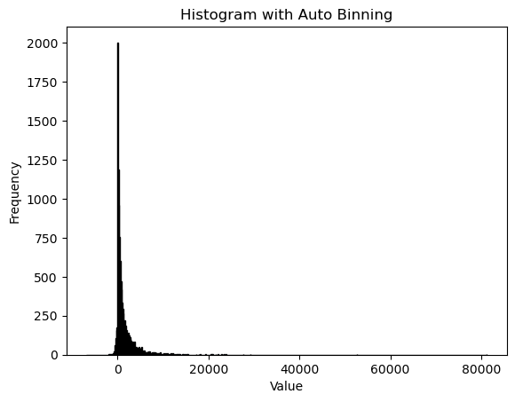

```python
# Convert the discrete Balance to continuous

# We will be using binning to identify the right no of bins that can be used in this case.

# Create a histogram and observe to finalize the number of bins
plt.hist(df['balance'], bins='auto', edgecolor='k')
plt.xlabel('Value')
plt.ylabel('Frequency')
plt.title('Histogram with Auto Binning')
plt.show()

#bins = [500,1000,1500,2000]
```

```python
df.isnull().sum()
```

```
age_range                  0
job                        0
marital                    0
education                  0
credit_default             0
balance                    0
housing_loan               0
personal_loan              0
contact_mode               0
day                        0
month                      0
duration                   0
campaign                   0
days_since_last_contact    0
previous                   0
poutcome                   0
deposit                    0
dtype: int64
```

```python
df.dtypes
```

```
age_range                  category
job                          object
marital                      object
education                    object
credit_default               object
balance                       int64
housing_loan                 object
personal_loan                object
contact_mode                 object
day                           int64
month                        object
duration                      int64
campaign                      int64
days_since_last_contact       int64
previous                      int64
poutcome                     object
deposit                      object
dtype: object
```

```python
df.info()
```

```
<class 'pandas.core.frame.DataFrame'>
RangeIndex: 11162 entries, 0 to 11161
Data columns (total 17 columns):
 #   Column                   Non-Null Count  Dtype
---  ------                   --------------  -----
 0   age_range                11162 non-null  category
 1   job                      11162 non-null  object
 2   marital                  11162 non-null  object
 3   education                11162 non-null  object
 4   credit_default           11162 non-null  object
 5   balance                  11162 non-null  int64
 6   housing_loan             11162 non-null  object
 7   personal_loan            11162 non-null  object
 8   contact_mode             11162 non-null  object
 9   day                      11162 non-null  int64
 10  month                    11162 non-null  object
 11  duration                 11162 non-null  int64
 12  campaign                 11162 non-null  int64
 13  days_since_last_contact  11162 non-null  int64
 14  previous                 11162 non-null  int64
 15  poutcome                 11162 non-null  object
 16  deposit                  11162 non-null  object
dtypes: category(1), int64(6), object(10)
memory usage: 1.4+ MB
```

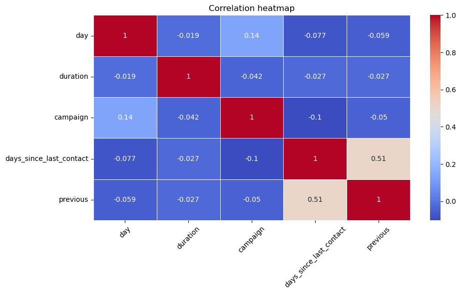

```python
#Checking for any highly correlated columns

df_corrleation = df[['credit_default',
                      'housing_loan','personal_loan','day','duration','campaign',
                      'days_since_last_contact','previous']]
corr_matrix = df_corrleation.corr()

plt.figure(figsize = (10,6))
sns.heatmap(corr_matrix,annot=True,cmap='coolwarm',linewidth=0.5)

#Add labels

plt.title('Correlation heatmap')
plt.xticks(rotation=45)
plt.tight_layout()

plt.show()
```

Identifying any possible correlation amongst the numerical fields:

```python
df['deposit'].unique()
```

```
array(['yes', 'no'], dtype=object)
```

```python
df
```

|  | age_range | job | marital | education | credit_default | balance | housing_loan | personal_loan | contact_mode | day | month | duration | campaign | days_since_last_contact | previous | poutcome | deposit |
| --- | --- | --- | --- | --- | --- | --- | --- | --- | --- | --- | --- | --- | --- | --- | --- | --- | --- |
| 0 | 51-60 | admin. | married | secondary | no | 2343 | yes | no | unknown | 5 | may | 1042 | 1 | -1 | 0 | unknown | yes |
| 1 | 51-60 | admin. | married | secondary | no | 45 | no | no | unknown | 5 | may | 1467 | 1 | -1 | 0 | unknown | yes |
| 2 | 41-50 | technician | married | secondary | no | 1270 | yes | no | unknown | 5 | may | 1389 | 1 | -1 | 0 | unknown | yes |
| 3 | 51-60 | services | married | secondary | no | 2476 | yes | no | unknown | 5 | may | 579 | 1 | -1 | 0 | unknown | yes |
| 4 | 51-60 | admin. | married | tertiary | no | 184 | no | no | unknown | 5 | may | 673 | 2 | -1 | 0 | unknown | yes |
| ... | ... | ... | ... | ... | ... | ... | ... | ... | ... | ... | ... | ... | ... | ... | ... | ... | ... |
| 11157 | 31-40 | blue-collar | single | primary | no | 1 | yes | no | cellular | 20 | apr | 257 | 1 | -1 | 0 | unknown | no |
| 11158 | 31-40 | services | married | secondary | no | 733 | no | no | unknown | 16 | jun | 83 | 4 | -1 | 0 | unknown | no |
| 11159 | 31-40 | technician | single | secondary | no | 29 | no | no | cellular | 19 | aug | 156 | 2 | -1 | 0 | unknown | no |
| 11160 | 41-50 | technician | married | secondary | no | 0 | no | yes | cellular | 8 | may | 9 | 2 | 172 | 5 | failure | no |
| 11161 | 31-40 | technician | married | secondary | no | 0 | no | no | cellular | 9 | jul | 628 | 1 | -1 | 0 | unknown | no |

11162 rows × 17 columns

```python
df.columns
```

```
Index(['age_range', 'job', 'marital', 'education', 'credit_default', 'balance',
       'housing_loan', 'personal_loan', 'contact_mode', 'day', 'month',
       'duration', 'campaign', 'days_since_last_contact', 'previous',
       'poutcome', 'deposit'],
      dtype='object')
```

```python
df.isnull().sum()
```

```
age_range                  0
job                        0
marital                    0
education                  0
credit_default             0
balance                    0
housing_loan               0
personal_loan              0
contact_mode               0
day                        0
month                      0
duration                   0
campaign                   0
days_since_last_contact    0
previous                   0
poutcome                   0
deposit                    0
dtype: int64
```

```python
df.groupby('deposit').count()
```

| deposit | age_range | job | marital | education | credit_default | balance | housing_loan | personal_loan | contact_mode | day | month | duration | campaign | days_since_last_contact | previous | poutcome |
| --- | --- | --- | --- | --- | --- | --- | --- | --- | --- | --- | --- | --- | --- | --- | --- | --- |
| no | 5873 | 5873 | 5873 | 5873 | 5873 | 5873 | 5873 | 5873 | 5873 | 5873 | 5873 | 5873 | 5873 | 5873 | 5873 | 5873 |
| yes | 5289 | 5289 | 5289 | 5289 | 5289 | 5289 | 5289 | 5289 | 5289 | 5289 | 5289 | 5289 | 5289 | 5289 | 5289 | 5289 |

### Evaluation Metric

In the context of this problem, False Postives (Predicting deposit was made when there was no deposit) might be have a higher negative impact than False Negatives(Not predicting a deposit that was done). Given the distribution in the classes and its effect on the business, we cannot depend on just one metric to make decision. We would be using multiple metric, measuring the cost impact of the error and making the right decision.

1. Precision: Precision is the ratio of true positive predictions to the total predicted positives (true positives + false positives). It measures the accuracy of positive predictions made by the model. Referred to when False Positives are costly.
2. Recall: Recall (or sensitivity) is the ratio of true positive predictions to the total actual positives (true positives + false negatives). It measures the model's ability to identify all relevant instances of the positive class. False negatives are costly, and you want to ensure that the model captures as many true positive instances as possible, even if it means accepting some false positives.
3. F1 Score: You want a balanced metric that considers both precision and recall. A single metric that reflects the trade-off between false positives and false negatives.

We would generating all these metric to support the overall accuracy and correctness of the model. This would be associated with the loss incurred due to missing out on a potential depositer or investing time to market the scheme to the wrong set of customers to judge the performance.

### Splitting into Train-Test

In our bank marketing dataset, we observe a commendable balance between the 'Yes' and 'No' classes. The equal distribution of readings across both classes indicates that the dataset is not heavily imbalanced. Given this characteristic, the advantages typically associated with employing cross-validation techniques, designed to address class imbalances, are somewhat diminished.

Moreover, considering the computational cost associated with certain advanced cross-validation methods, it becomes an overhead load along with its benfits. In our case, with a dataset exhibiting a descent distribution and a limited sample size, opting for elaborate cross-validation may not yield significant advantages and could unnecessarily increase computational expenses.

Hence, given the dataset's balanced nature and its manageable size, we've chosen a 80-20 split approach for training and testing. This split allows for an effective evaluation of the model's performance while maintaining computational efficiency. By reserving 20% of the data for testing, we strike a reasonable balance between thorough model evaluation and resource optimization."

### Choosing Cross Columns

Contextual Reasoning for choosing these pairs:

1. ['age_range', 'job', 'marital', 'education']: This combination helps identify and calculate a joint estimation of the effect of all the demographic factors on the decision to deposit by the customer.
2. ['job', 'marital', 'education', 'contact_mode']: It helps identify the general trend that can be established when the personal traits of a person and the contact mode have when making a decision to deposit.
3. ['housing_loan', 'personal_loan', 'contact_mode']: This helps identify that if contacted and that customner has a overhead financial load, what will be their decision to deposit in the bank.
4. ['education', 'poutcome']: This establishes any lose connection that might exist between the previous deposit decision and education on the current decision to deposit.
5. ['age_range', 'housing_loan', 'personal_loan']: This helps relate on how age and overhead financial load contribute to the decision to deposit.
6. ['job', 'education', 'contact_mode']: This mainly helps identify the relation between the job and education of the customer. And what impact does contacting them have on the decision to deposit.
7. ['marital', 'housing_loan', 'contact_mode']: This mainly establishes a relation between being married and having a housing loan for living. And if contacted, what are the chances to invest in the deposit.

We observed that these combinations covered any additional information that could be covered by our Network and that might be helpful for training our Network Model

### Encoding and Scaling

```python
from sklearn.model_selection import train_test_split
df_train, df_test = train_test_split(df, test_size=0.2, random_state=42)
```

```python
from sklearn.preprocessing import LabelEncoder
from sklearn.preprocessing import StandardScaler

# Define objects that can encode each variable as an integer
encoders = dict()  # Save each encoder in a dictionary

categorical_headers = ['age_range', 'job', 'marital', 'education', 'credit_default','housing_loan', 'personal_loan', 'contact_mode','month','poutcome']

# Combine training and test data for label encoding
combined_data = pd.concat([df_train, df_test], ignore_index=True)

# Train all encoders (special case the target 'customer_status')
for col in categorical_headers + ['deposit']:
    combined_data[col] = combined_data[col].str.strip()

    if col == "deposit":
        # Special case the target, just replace the column
        tmp = LabelEncoder()
        combined_data[col] = tmp.fit_transform(combined_data[col])
    else:
        # Integer encode strings that are features
        encoders[col] = LabelEncoder()  # Save the encoder
        combined_data[col + '_int'] = encoders[col].fit_transform(combined_data[col])

# Split the combined data back into training and test sets
df_train = combined_data.iloc[:len(df_train)]
df_test = combined_data.iloc[len(df_train):]

# Scale the numeric, continuous variables
numerical_headers = ['balance','day','duration', 'campaign', 'days_since_last_contact','previous']

ss = StandardScaler()
df_train[numerical_headers] = ss.fit_transform(df_train[numerical_headers].values)
df_test[numerical_headers] = ss.transform(df_test[numerical_headers].values)

df_test.head()
```

|  | age_range | job | marital | education | credit_default | balance | housing_loan | personal_loan | contact_mode | day | ... | age_range_int | job_int | marital_int | education_int | credit_default_int | housing_loan_int | personal_loan_int | contact_mode_int | month_int | poutcome_int |
| --- | --- | --- | --- | --- | --- | --- | --- | --- | --- | --- | --- | --- | --- | --- | --- | --- | --- | --- | --- | --- | --- |
| 8929 | 61-70 | retired | divorced | secondary | no | -0.247693 | no | no | cellular | -1.258740 | ... | 5 | 5 | 0 | 1 | 0 | 0 | 0 | 0 | 5 | 3 |
| 8930 | 31-40 | blue-collar | married | secondary | no | 0.033970 | no | no | unknown | 0.043817 | ... | 2 | 1 | 1 | 1 | 0 | 0 | 0 | 2 | 6 | 3 |
| 8931 | 31-40 | blue-collar | single | secondary | no | 1.098101 | yes | no | cellular | -0.193012 | ... | 2 | 1 | 2 | 1 | 0 | 1 | 0 | 0 | 8 | 0 |
| 8932 | 41-50 | blue-collar | married | secondary | no | 2.139904 | no | no | cellular | -0.903498 | ... | 3 | 1 | 1 | 1 | 0 | 0 | 0 | 0 | 1 | 3 |
| 8933 | 31-40 | technician | married | tertiary | no | -0.015154 | yes | no | unknown | -0.429840 | ... | 2 | 9 | 1 | 2 | 0 | 1 | 0 | 2 | 8 | 3 |

5 rows × 27 columns

```python
import numpy as np
categorical_headers_ints = [x+'_int' for x in categorical_headers]

feature_columns = categorical_headers_ints+numerical_headers

import pprint
pp = pprint.PrettyPrinter(indent=4)

print(f"We will use the following {len(feature_columns)} features:")
pp.pprint(feature_columns)

# combine the features into a single large matrix
X_train = df_train[feature_columns]
X_test = df_test[feature_columns]

y_train = df_train['deposit']
y_test = df_test['deposit']
```

```
We will use the following 16 features:
[   'age_range_int',
    'job_int',
    'marital_int',
    'education_int',
    'credit_default_int',
    'housing_loan_int',
    'personal_loan_int',
    'contact_mode_int',
    'month_int',
    'poutcome_int',
    'balance',
    'day',
    'duration',
    'campaign',
    'days_since_last_contact',
    'previous']
```

### Multi Layer Perceptron

```python
X_train_categorical = X_train[categorical_headers_ints]
X_test_categorical = X_test[categorical_headers_ints]
X_train_numerical = X_train[numerical_headers]
X_test_numerical = X_test[numerical_headers]
```

```python
from tensorflow.keras.layers import Embedding
from tensorflow.keras.layers import concatenate
import tensorflow as tf
from tensorflow.keras.layers import Input, Embedding, Dense, concatenate
from tensorflow.keras.models import Model

# start by getting only the categorical variables
# these matrices are all integers
X_train = df_train[categorical_headers_ints].to_numpy()
X_test = df_test[categorical_headers_ints].to_numpy()

embed_branches = []
all_branch_outputs = [] # this is where we will keep track of output of each branch

# feed in the entire matrix of categircal variables
input_branch = Input(shape=(X_train.shape[1],),
                     dtype='int64',
                     name='categorical')

# for each categorical variable
for idx,col in enumerate(categorical_headers_ints):

    # what the maximum integer value for this variable?
    # which is the same as the number of categories
    # these lines of code do the same thing
    N = max(df_train[col].max(),df_test[col].max())+1
    N = len(encoders[categorical_headers[idx]].classes_)

    # this line of code does this: input_branch[:,idx]
    x = tf.gather(input_branch, idx, axis=1)

    # now use an embedding to deal with integers as if they were one hot encoded
    x = Embedding(input_dim=N,
                  output_dim=int(np.sqrt(N)),
                  input_length=1, name=col+'_embed')(x)

    # save these outputs in list to concatenate later
    all_branch_outputs.append(x)

# now concatenate the outputs and add a fully connected layer
final_branch = concatenate(all_branch_outputs, name='concat_1')
final_branch = Dense(units=1,
                     activation='sigmoid',
                     name='combined')(final_branch)

model = Model(inputs=input_branch, outputs=final_branch)

model.compile(optimizer='sgd',
              loss='mean_squared_error',
              metrics=['accuracy'])

model.summary()
```

```
Model: "model"
__________________________________________________________________________________________________
 Layer (type)                Output Shape                 Param #   Connected to
==================================================================================================
 categorical (InputLayer)    [(None, 10)]                 0         []

 tf.compat.v1.gather (TFOpL  (None,)                      0         ['categorical[0][0]']
 ambda)

 tf.compat.v1.gather_1 (TFO  (None,)                      0         ['categorical[0][0]']
 pLambda)

 tf.compat.v1.gather_2 (TFO  (None,)                      0         ['categorical[0][0]']
 pLambda)

 tf.compat.v1.gather_3 (TFO  (None,)                      0         ['categorical[0][0]']
 pLambda)

 tf.compat.v1.gather_4 (TFO  (None,)                      0         ['categorical[0][0]']
 pLambda)

 tf.compat.v1.gather_5 (TFO  (None,)                      0         ['categorical[0][0]']
 pLambda)

 tf.compat.v1.gather_6 (TFO  (None,)                      0         ['categorical[0][0]']
 pLambda)

 tf.compat.v1.gather_7 (TFO  (None,)                      0         ['categorical[0][0]']
 pLambda)

 tf.compat.v1.gather_8 (TFO  (None,)                      0         ['categorical[0][0]']
 pLambda)

 tf.compat.v1.gather_9 (TFO  (None,)                      0         ['categorical[0][0]']
 pLambda)

 age_range_int_embed (Embed  (None, 3)                    27        ['tf.compat.v1.gather[0][0]']
 ding)

 job_int_embed (Embedding)   (None, 3)                    36        ['tf.compat.v1.gather_1[0][0]'
```

[output cut: 33 more lines]

```
                                                                    ',
                                                                     'personal_loan_int_embed[0][0
                                                                    ]',
                                                                     'contact_mode_int_embed[0][0]
                                                                    ',
                                                                     'month_int_embed[0][0]',
                                                                     'poutcome_int_embed[0][0]']

 combined (Dense)            (None, 1)                    19        ['concat_1[0][0]']

==================================================================================================
Total params: 146 (584.00 Byte)
Trainable params: 146 (584.00 Byte)
Non-trainable params: 0 (0.00 Byte)
__________________________________________________________________________________________________
```

```python
%%time

model.fit(X_train, y_train, epochs=10, batch_size=50, verbose=1)

from sklearn import metrics as mt
yhat_proba = model.predict(X_test)
yhat = np.round(yhat_proba)
print(mt.confusion_matrix(y_test,yhat))
print(mt.classification_report(y_test,yhat))
```

```
[[1102   64]
 [ 798  269]]
              precision    recall  f1-score   support

           0       0.58      0.95      0.72      1166
           1       0.81      0.25      0.38      1067

    accuracy                           0.61      2233
   macro avg       0.69      0.60      0.55      2233
weighted avg       0.69      0.61      0.56      2233

CPU times: user 1.01 s, sys: 211 ms, total: 1.22 s
Wall time: 897 ms
```

### Evaluating the Performance of Multi Layer Perceptron:

Accuracy%: 61%

**Confusion Matrix:**

|  | Predicted 0 | Predicted 1 |
| --- | --- | --- |
| **Actual 0** | 1102 | 64 |
| **Actual 1** | 798 | 269 |

**Classification Report:**

| Class | Precision | Recall | F1-Score | Support |
| --- | --- | --- | --- | --- |
| 0 | 0.58 | 0.95 | 0.72 | 1166 |
| 1 | 0.81 | 0.25 | 0.38 | 1067 |

We can observe that the number of False Negatives are quite high as compared to the True Positives. However, the False Positives look to be reasonale as compared to other classifed cases. This indicated better Precion but a poor Recall in the cases where the deposits were made. Also, we could observe that the model captures the cases where the deposits were not made better as compared to the cases where deposits where made.

## Creating a Combined Wide and Deep Network

### Creating a wide Network

```python
cross_columns = [
    ['age_range', 'job', 'marital', 'education'],
     ['job', 'marital', 'education', 'contact_mode'],
     ['housing_loan', 'personal_loan', 'contact_mode'],
     ['education', 'poutcome'],
     ['age_range', 'housing_loan', 'personal_loan'],
     ['job', 'education', 'contact_mode'],
     ['marital', 'housing_loan', 'contact_mode']
]


# cross each set of columns in the list above
cross_col_df_names = []
for cols_list in cross_columns:
    # encode as ints for the embedding
    enc = LabelEncoder()

    # 1. create crossed labels by join operation
    X_crossed_train = df_train[cols_list].apply(lambda x: '_'.join(x), axis=1)
    X_crossed_test = df_test[cols_list].apply(lambda x: '_'.join(x), axis=1)

    cross_col_name = '_'.join(cols_list)

    # 2. encode as integers, stacking all possibilities
    enc.fit(np.hstack((X_crossed_train.to_numpy(),  X_crossed_test.to_numpy())))

    # 3. Save into dataframe with new name
    df_train[cross_col_name] = enc.transform(X_crossed_train)
    df_test[cross_col_name] = enc.transform(X_crossed_test)

    # Save the encoder used here for later:
    encoders[cross_col_name] = enc

    # keep track of the new names of the crossed columns
    cross_col_df_names.append(cross_col_name)

cross_col_df_names
```

```
['age_range_job_marital_education',
 'job_marital_education_contact_mode',
 'housing_loan_personal_loan_contact_mode',
 'education_poutcome',
 'age_range_housing_loan_personal_loan',
 'job_education_contact_mode',
 'marital_housing_loan_contact_mode']
```

```python
#running the wide model
X_train_crossed = df_train[cross_col_df_names].to_numpy()
X_test_crossed = df_test[cross_col_df_names].to_numpy()

crossed_outputs = [] # this is where we will keep track of output of each branch

input_crossed = Input(shape=(X_train_crossed.shape[1],), dtype='int64', name='categorical')
for idx,col in enumerate(cross_col_df_names):

    # track what the maximum integer value will be for this variable
    # which is the same as the number of categories
    N = max(df_train[col].max(),df_test[col].max())+1
    N = len(encoders[col].classes_)
    N_reduced = int(np.sqrt(N))

    # this line of code does this: input_branch[:,idx]
    x = tf.gather(input_crossed, idx, axis=1)

    # now use an embedding to deal with integers as if they were one hot encoded
    x = Embedding(input_dim=N,
                  output_dim=N_reduced,
                  input_length=1, name=col+'_embed')(x)

    # save these outputs to concatenate later
    crossed_outputs.append(x)


# now concatenate the outputs and add a fully connected layer
wide_branch = concatenate(crossed_outputs, name='concat_1')
wide_branch = Dense(units=1,activation='sigmoid', name='combined')(wide_branch)

model = Model(inputs=input_crossed, outputs=wide_branch)

model.compile(optimizer='sgd',
              loss='mean_squared_error',
              metrics=['accuracy'])

model.fit(X_train_crossed,
        y_train, epochs=10, batch_size=32, verbose=1)
```

```
<keras.src.callbacks.History at 0x28fcc9550>
```

```python
model.fit(X_train_crossed,
        y_train, epochs=10, batch_size=32, verbose=1)
```

```
<keras.src.callbacks.History at 0x28fed3250>
```

```python
yhat = np.round(model.predict(X_test_crossed))
print(mt.confusion_matrix(y_test,yhat))
print(mt.classification_report(y_test,yhat))
```

```
[[856 310]
 [481 586]]
              precision    recall  f1-score   support

           0       0.64      0.73      0.68      1166
           1       0.65      0.55      0.60      1067

    accuracy                           0.65      2233
   macro avg       0.65      0.64      0.64      2233
weighted avg       0.65      0.65      0.64      2233
```

```python
deep_embed = []
X_train_crossed = df_train[cross_col_df_names].to_numpy()
X_test_crossed = df_test[cross_col_df_names].to_numpy()

# save categorical features
X_train_cat = df_train[categorical_headers_ints].to_numpy()
X_test_cat = df_test[categorical_headers_ints].to_numpy()

# and save off the numeric features
X_train_num =  df_train[numerical_headers].to_numpy()
X_test_num = df_test[numerical_headers].to_numpy()

def create_and_train_model(optimizer, epochs, batch_size):

    # we need to create separate lists for each branch
    crossed_outputs = []

    # CROSSED DATA INPUT
    input_crossed = Input(shape=(X_train_crossed.shape[1],), dtype='int64', name='wide_inputs')
    for idx,col in enumerate(cross_col_df_names):

        # track what the maximum integer value will be for this variable
        # which is the same as the number of categories
        N = max(df_train[col].max(),df_test[col].max())+1
        N = len(encoders[col].classes_)
        N_reduced = int(np.sqrt(N))


        # this line of code does this: input_branch[:,idx]
        x = tf.gather(input_crossed, idx, axis=1)

        # now use an embedding to deal with integers as if they were one hot encoded
        x = Embedding(input_dim=N,
                      output_dim=N_reduced,
                      input_length=1, name=col+'_embed')(x)

        # save these outputs to concatenate later
        crossed_outputs.append(x)


    # now concatenate the outputs and add a fully connected layer
    wide_branch = concatenate(crossed_outputs, name='wide_concat')

    # reset this input branch
    all_deep_branch_outputs = []


    # CATEGORICAL DATA INPUT
    input_cat = Input(shape=(X_train_cat.shape[1],), dtype='int64', name='categorical_input')
    for idx,col in enumerate(categorical_headers_ints):

        # track what the maximum integer value will be for this variable
        # which is the same as the number of categories
        N = max(df_train[col].max(),df_test[col].max())+1
        N_reduced = int(np.sqrt(N))

        # this line of code does this: input_branch[:,idx]
        x = tf.gather(input_cat, idx, axis=1)

        # now use an embedding to deal with integers as if they were one hot encoded
        x = Embedding(input_dim=N,
                      output_dim=N_reduced,
                      input_length=1, name=col+'_embed')(x)

        # save these outputs to concatenate later
        all_deep_branch_outputs.append(x)

    # NUMERIC DATA INPUT
    # create dense input branch for numeric
    input_num = Input(shape=(X_train_num.shape[1],), name='numeric')
    x_dense = Dense(units=20, activation='relu',name='num_1')(input_num)
    all_deep_branch_outputs.append(x_dense)

    deep_embed.append(all_deep_branch_outputs)


    # merge the deep branches together
    deep_branch = concatenate(all_deep_branch_outputs,name='concat_embeds')
    deep_branch = Dense(units=50,activation='relu', name='deep1')(deep_branch)
    deep_branch = Dense(units=25,activation='relu', name='deep2')(deep_branch)
    deep_branch = Dense(units=10,activation='relu', name='deep3')(deep_branch)

    # merge the deep and wide branch
    final_branch = concatenate([wide_branch, deep_branch],
                               name='concat_deep_wide')
    final_branch = Dense(units=1,activation='sigmoid',
                         name='combined')(final_branch)

    model = Model(inputs=[input_crossed,input_cat,input_num],
                  outputs=final_branch)

    model.compile(optimizer=optimizer, loss='mean_squared_error', metrics=['accuracy'])

    # Train the model and store the training history
    history = model.fit([X_train_crossed, X_train_cat, X_train_num],
                        y_train,
                        epochs=epochs,
                        batch_size=batch_size,
                        verbose=1,
                        validation_data=([X_test_crossed, X_test_cat, X_test_num], y_test))

    y_probs = model.predict([X_test_crossed, X_test_cat, X_test_num])
    yhat = np.round(y_probs)
    print(mt.confusion_matrix(y_test,yhat))
    print(mt.classification_report(y_test,yhat))

    # Compute ROC curve and AUC
    fpr, tpr, thresholds = roc_curve(y_test, y_probs)
    roc_auc = auc(fpr, tpr)

    # Plot ROC curve
    plt.figure(figsize=(8, 6))
    plt.plot(fpr, tpr, color='darkorange', lw=2, label=f'Model (AUC = {roc_auc:.2f})')
    plt.plot([0, 1], [0, 1], color='navy', lw=2, linestyle='--')
    plt.xlabel('False Positive Rate')
    plt.ylabel('True Positive Rate')
    plt.title('Receiver Operating Characteristic (ROC) Curve')
    plt.legend(loc='lower right')
    plt.show()

    # Print AUC score
    print(f'AUC: {roc_auc:.2f}')


    return history,roc_auc
```

```
[[1004  162]
 [ 466  601]]
              precision    recall  f1-score   support

           0       0.68      0.86      0.76      1166
           1       0.79      0.56      0.66      1067

    accuracy                           0.72      2233
   macro avg       0.74      0.71      0.71      2233
weighted avg       0.73      0.72      0.71      2233
```

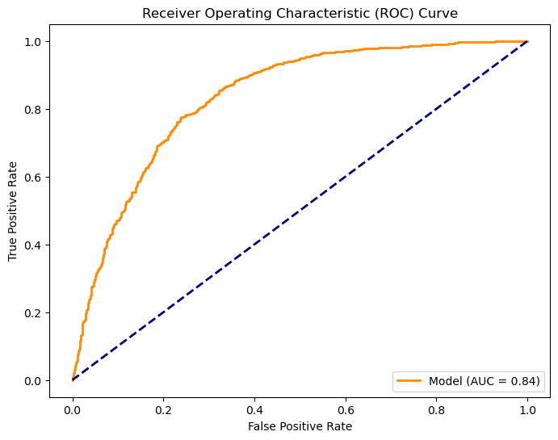

```
AUC: 0.84
[[942 224]
 [146 921]]
              precision    recall  f1-score   support

           0       0.87      0.81      0.84      1166
           1       0.80      0.86      0.83      1067

    accuracy                           0.83      2233
   macro avg       0.84      0.84      0.83      2233
weighted avg       0.84      0.83      0.83      2233
```

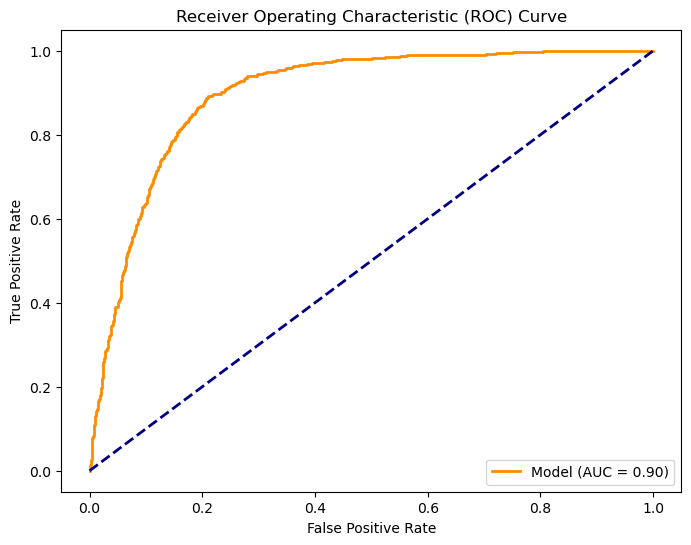

```
AUC: 0.90
[[926 240]
 [131 936]]
              precision    recall  f1-score   support

           0       0.88      0.79      0.83      1166
           1       0.80      0.88      0.83      1067

    accuracy                           0.83      2233
   macro avg       0.84      0.84      0.83      2233
weighted avg       0.84      0.83      0.83      2233
```

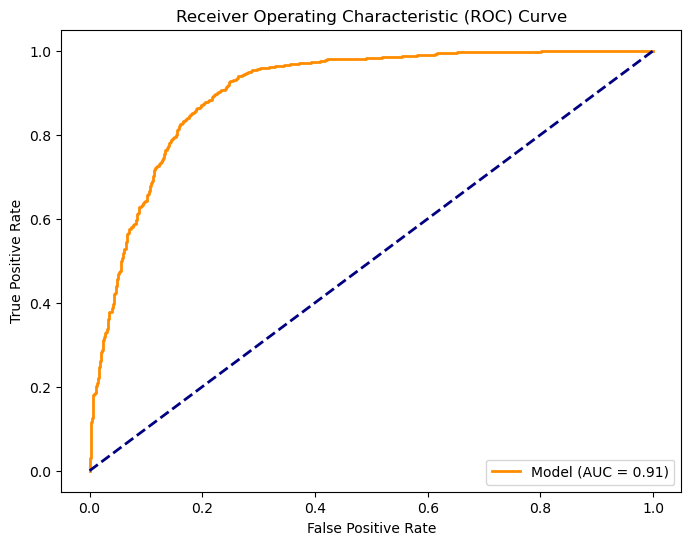

```
AUC: 0.91
```

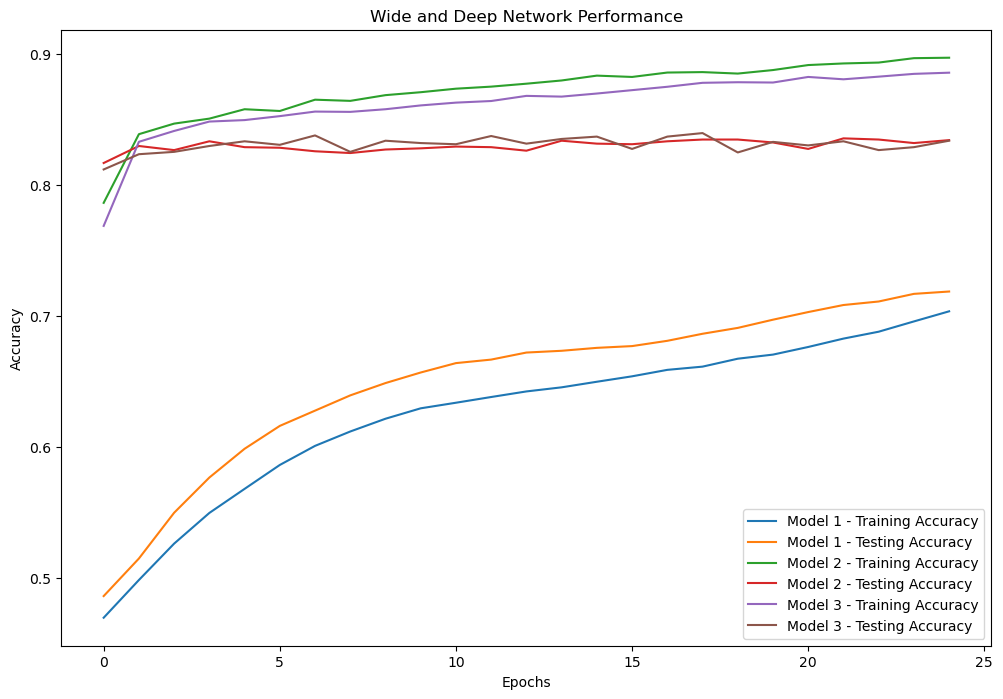

```
Best Model is Model 3
```

```python
from sklearn.metrics import roc_curve
from sklearn.metrics import auc



model_histories = []

# Model 1


history_1, roc_auc_1 = create_and_train_model(optimizer='adagrad', epochs=25, batch_size=32)
model_histories.append(('Model 1', history_1))

# Model 2
history_2, roc_auc_2 = create_and_train_model(optimizer='adam', epochs=25, batch_size=32)
model_histories.append(('Model 2', history_2))

# Model 3
history_3, roc_auc_3 = create_and_train_model(optimizer='rmsprop', epochs=25, batch_size=32)
model_histories.append(('Model 3', history_3))

# Visualize the performance of the models
plt.figure(figsize=(12, 8))

for model_name, history in model_histories:
    plt.plot(history.history['accuracy'], label=f'{model_name} - Training Accuracy')
    plt.plot(history.history['val_accuracy'], label=f'{model_name} - Testing Accuracy')

plt.title('Wide and Deep Network Performance')
plt.xlabel('Epochs')
plt.ylabel('Accuracy')
plt.legend()
plt.show()

best_model_index = np.argmax([roc_auc_1, roc_auc_2, roc_auc_3])  # Adjust with actual AUC scores
best_model_name = ['Model 1', 'Model 2', 'Model 3'][best_model_index]
print("Best Model is " + best_model_name)
```

### Evaluating the Deep Wide Network:

When building this Deep-Wide Network, we have used three models that would called with various different set of optimizers that would be used on that iteration of the model. They keep buiding and learning on each other. When we run 3 different instances of the same model with various parameter combination, we could observe that Model 3 gave us the best result. Thus we would considering Model 3 for further evaluations

Parameter combinations: We kept the number of epochs and batch size constant for all the models. However, We tried various combination of optimizers. We, then came to a conclusion that the combination where: Model1 used adagrad , Model2 used adam, & Model3 used rmsprop gives us the best accuaracy as a index of correctness. Also the our evaluation metrics of Precision, Recall and F1 score made sense as our aim to reduce the False readings that occurred in the model

As an added point of referencesm we also plotted across the ROC curves for all the Models. It showed the how every model performed when compared the ideal case in identifying the True Positive cases. Our models showed great precision as the overall rates of right identfying the positive cases (deposits made) were quite consistent.

Finally, we plotted the training and testing accuracy for all the models to understand comparative performance of the models amongst each other.

Based on the AUC scores (distinguishing abilities to categroize positive and negative labels - calculated from ROC), we concluded that Model3 performed the best amongst the three models that we ran.

Evaluation of Model3:

Accuracy: 83%

AUC: 0.91

**Confusion Matrix:**

|  | Predicted 0 | Predicted 1 |
| --- | --- | --- |
| **Actual 0** | 926 | 240 |
| **Actual 1** | 131 | 936 |

**Classification Report:**

| Label | Precision | Recall | F1-Score | Support |
| --- | --- | --- | --- | --- |
| 0 | 0.88 | 0.79 | 0.83 | 1166 |
| 1 | 0.80 | 0.88 | 0.83 | 1067 |

We can observe that the number of False Positive and False Negative cases are very less as compared to True Positive cases. Also, the model is rightly able to maintain a balance between identifying the positive and negative classes to be predicted. Thus, it has good high Precision, Recall and F1 scores that suggest that model is learning the right trend from the training data.

### Comparing the Multi layer Perceptron (MLP) with the Wide Deep Network (WDN):

We would be comparing MLP with WDN based on the following metric. We will be considering the performance only from the angle where in the positive class, i.e. the deposit = yes are being clasified correctly as that is more valuable to for this use cases as we don't to lose any potential customers.

| Metric | MLP | WDN |
| --- | --- | --- |
| **Accuracy** | 61% | 83% |
| **Precision** | 81% | 80% |
| **Recall** | 25% | 88% |
| **F1 Score** | 38% | 83% |

It can be clearly seen that the Wide Deep Networks is overpowered and learning trends and patterns faster as compared to the Multi layer Perceptron. As training for WDN is a continuous process with options to include more unseen patterns, handle extreme cases, modify parameters at various intervals and more room to learn on, WDN outperforms MLP atleast in this classification case though Precision for the Positive class looks to be better forming for MLP

### Dimensionality Reduction and Patterns in the Weight Matrix of the Network

```python
from tensorflow.keras.layers import Embedding
from tensorflow.keras.models import Model

# Assuming you have a Keras model named 'model'
embedding_layers = [layer.name for layer in model.layers if isinstance(layer, Embedding)]

print("List of embedding layers:", embedding_layers)
```

[output not shown]

```python
#Layers involved in the model
for layer in model.layers:
    print(layer.name)
```

```
categorical
tf.compat.v1.gather_10
tf.compat.v1.gather_11
tf.compat.v1.gather_12
tf.compat.v1.gather_13
tf.compat.v1.gather_14
tf.compat.v1.gather_15
tf.compat.v1.gather_16
age_range_job_marital_education_embed
job_marital_education_contact_mode_embed
housing_loan_personal_loan_contact_mode_embed
education_poutcome_embed
age_range_housing_loan_personal_loan_embed
job_education_contact_mode_embed
marital_housing_loan_contact_mode_embed
concat_1
combined
```

```python
import tensorflow as tf

# Assuming model is your trained neural network model
model = model  # Replace 'model' with the variable representing your trained model

# Initialize a list to store embedding layer weights
embedding_layer_weights_list = []

# Iterate through all layers in the model
for layer in model.layers:
    # Check if the layer is an Embedding layer
    if isinstance(layer, tf.keras.layers.Embedding):
        # Get the weights of the Embedding layer
        embedding_layer_weights = layer.get_weights()[0]
        # Append the weights to the list
        embedding_layer_weights_list.append(embedding_layer_weights)
```

```python
embedding_layer_weights_list[1]
```

```
array([[-0.01218052, -0.03984193, -0.02292915, ..., -0.00593315,
         0.03757886, -0.03508529],
       [ 0.04218105,  0.00428472, -0.0489229 , ..., -0.01178157,
         0.03535475,  0.04068194],
       [-0.03671789, -0.03925067,  0.020926  , ...,  0.02312899,
         0.04593399, -0.01551442],
       ...,
       [ 0.0195744 ,  0.02091873, -0.02195829, ...,  0.04420594,
        -0.00446529,  0.03147789],
       [ 0.03002118,  0.03762759,  0.04134731, ...,  0.01508642,
        -0.01149531,  0.04424486],
       [-0.02217213, -0.00846831,  0.01780205, ...,  0.04478471,
        -0.04250771, -0.01617572]], dtype=float32)
```

```python
len(embedding_layer_weights_list)
```

```
7
```

```python
import tensorflow as tf

model = model
# Initialize a list to store embedding layer weights
embedding_layer_weights_list = []

# Initialize a list to store corresponding labels
labels = []

for layer in model.layers:
    # Check if the layer is an Embedding layer
    if isinstance(layer, tf.keras.layers.Embedding):
        # Get the weights of the Embedding layer
        embedding_layer_weights = layer.get_weights()[0]
        # Append the weights to the list
        embedding_layer_weights_list.append(embedding_layer_weights)
        # Append corresponding labels (you need to replace this with your actual labels)
        labels.append("label_for_embedding_layer")

# Check consistency of lengths
if len(embedding_layer_weights_list) != len(labels):
    raise ValueError("Number of embedding layer weights and labels do not match.")
```

```
Number of data points: 7
Number of weight matrices: 7
Shape of weight matrix array: (7, 501, 22)
Number of data points: 7
Number of reduced dimensions: 7
```

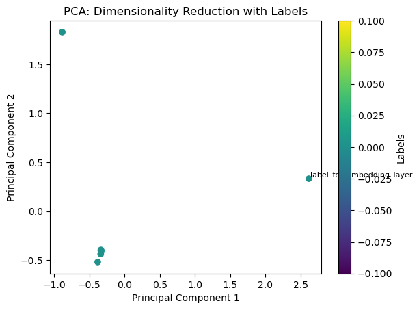

```python
import numpy as np
from sklearn.decomposition import PCA
from sklearn.preprocessing import LabelEncoder
import matplotlib.pyplot as plt

# Label encoding
label_encoder = LabelEncoder()
encoded_labels = label_encoder.fit_transform(labels)

# Save the label encoder mapping
label_mapping = dict(zip(label_encoder.classes_, label_encoder.transform(label_encoder.classes_)))

# Find the maximum shape among weight matrices
max_shape = max(w.shape for w in embedding_layer_weights_list)

# Pad or truncate weight matrices to have the same shape
padded_weights = [np.pad(w, ((0, max_shape[0] - w.shape[0]), (0, max_shape[1] - w.shape[1])), 'constant') for w in embedding_layer_weights_list]

# Convert the list of matrices to a 3D array
weight_matrix = np.array(padded_weights)

# Reshape the 3D array to a 2D array
flattened_weights = weight_matrix.reshape((weight_matrix.shape[0], -1))

# Check the shapes
print("Number of data points:", len(labels))
print("Number of weight matrices:", len(embedding_layer_weights_list))
print("Shape of weight matrix array:", weight_matrix.shape)

# Initialize PCA with the desired number of components (e.g., 2 for 2D visualization)
pca = PCA(n_components=2)

# Fit and transform the data
reduced_dimensions = pca.fit_transform(flattened_weights)

# Check the shapes
print("Number of data points:", len(labels))
print("Number of reduced dimensions:", reduced_dimensions.shape[0])

# Ensure the dimensions match
assert len(labels) == weight_matrix.shape[0], "Number of data points and weight matrices do not match."

# Plot the reduced dimensions with colored points based on labels
scatter = plt.scatter(reduced_dimensions[:, 0], reduced_dimensions[:, 1], c=encoded_labels, cmap='viridis')

# Add labels
for label, idx in label_mapping.items():
    plt.text(reduced_dimensions[idx, 0] + 0.02, reduced_dimensions[idx, 1] + 0.02, str(label), fontsize=8)

# Add a colorbar
plt.colorbar(scatter, label='Labels')

plt.xlabel('Principal Component 1')
plt.ylabel('Principal Component 2')
plt.title('PCA: Dimensionality Reduction with Labels')

# Show the plot
plt.show()
```

From this scatter plot, we can observe that certain points have quite close resemblence to each other when defined a two dimensional space. We can mainly observe three clusters of points. In those three clusters, one looks to be having a higher collection of points that indicates resemblence in the characterstics of features amongst these points.

## References:

1. [UCI]. Marketing Dataset. Retrieved from https://archive.ics.uci.edu/dataset/222/bank+marketing
2. [Kaggle]. Marketing Dataset. Retrieved from https://www.kaggle.com/datasets/janiobachmann/bank-marketing-dataset
3. Moro, S., Cortez, P. & Rita, P. (2014). A data-driven approach to predict the success of bank telemarketing. Decision Support Systems. 62, 22-31 https://dx.doi.org/10.1016/j.dss.2014.03.001
4. https://github.com/eclarson/MachineLearningNotebooks/blob/master/10.%20Keras%20Wide%20and%20Deep.ipynb